# Final Project

Bingkai Wang

September 20, 2017

## The question is:

Perform an analysis of “data scientist” jobs listed on job boards and on the employment pages of major companies. What are the most common skills that employers look for? What are the most unique skills that employers look for? Where are the types of companies that employ the most data scientists?

```r
library(rvest) # web scraping
library(dplyr) # data cleaning
library(stringr); library(tidytext) # text processing
library(ggplot2);library(ggmap);library(wordcloud) # data visualization
```

### Step 1 Scraping data from Glassdoor.com with job title ‘data scientist’

In this step, we use package **rvest** to scrape and collect raw data for company name, location (city, state) and job description. We then output a csv file containing these information.

For testing, we only scrape five pages of jobs in the website. And the following code could be easily generated for hundreds of pages.

```r
#Initializing
company <- rep(NA, 10000)
location <- rep(NA, 10000)
description <- rep(NA, 10000)
companysize <- rep(NA, 10000)
industry <- rep(NA, 10000)
currentpage <- html_session("https://www.glassdoor.com/Job/jobs.htm?suggestCount=0&suggestChosen=true&clickSource=searchBtn&typedKeyword=data+sc&sc.keyword=data+scientist&locT=&locId=&jobType=")
count <- 0 # count the number of jobs
ptm <- proc.time()
# scaping. 'i' is the index of page.
# Currently use page 1 to 5 with each containing roughly 30 jobs.
for(i in 1:5){
  link <- currentpage %>% html_nodes("a.jobLink") %>% html_attr("href")
  link <- paste('https://www.glassdoor.com', link, sep = '')
  link <- unique(link)
  for(j in link){
    subpage <- html_session(j) # jump to the second level webpage
    if(grepl("glassdoor", subpage$url)){
      add_company <- subpage %>% html_node(".padRtSm") %>% html_text()
      if(is.na(add_company) | add_company %in% company){
        next
      }else{
        count <- count + 1
        company[count] <- add_company
        location[count] <- subpage %>% html_node(".subtle") %>% html_text()
        description[count] <- subpage %>% html_node(".desc") %>% html_text()
      }
    }
    sourcefile <- suppressWarnings(readLines(j))
    pinpoint <- grep("employer", sourcefile)

    sourcefile <- sourcefile[pinpoint[1]+ 0:20]
    current_industry <- sourcefile[str_detect(sourcefile, "\'industry\'")] %>%
      str_extract("\"(.*)\"") %>%
      str_sub(2, -2)
    industry[count] <- if(length(current_industry)>0){current_industry}else{NA}
    current_size <- sourcefile[str_detect(sourcefile, "\'size\'")] %>%
      str_extract("\"(.*)\"") %>%
      str_sub(2, -2)
    companysize[count] <- if(length(current_size)>0){current_size}else{NA}
  }
  # navigate to next page
  nextpage <- currentpage %>% html_nodes("#FooterPageNav a") %>% html_attr("href")
  nextpage <- paste('www.glassdoor.com', nextpage, sep = '')
  currentpage <- html_session(nextpage[length(nextpage)])

  Sys.sleep(5)
}
proc.time() - ptm
# preprocessing location data for output
location <- location[1:count] %>%
  sapply(function(s) substr(s, 5, nchar(s))) %>%
  str_split(", ")
for(i in 1: count){
  n <- length(location[[i]])
  if(n == 1){
    location[[i]] <- c(NA, NA)
  }else if(n > 2){
    location[[i]] <- location[[i]][-(1:(n-2))]
  }
}
location <- t(as.data.frame(location))

#output data frame
demo_raw_data <- data.frame(company = trimws(company[1:count]),
                            city = location[,1],
                            state = location[,2],
                            description = description[1:count],
                            companysize = companysize[1:count],
                            industy = str_replace_all(industry[1:count], "&amp;", "&"))
rownames(demo_raw_data) <- NULL

write.csv(demo_raw_data, "demo_raw_data.csv")
```

The raw data looks like:

```
##   X                    company      city state
## 1 1               ID Analytics San Diego    CA
## 2 2          HUB International   Chicago    IL
## 3 3     Raise Marketplace Inc.  New York    NY
## 4 4   GCP Applied Technologies Cambridge    MA
## 5 5 America First Credit Union     Ogden    UT
## 6 6                    Novetta   Herndon    VA
##                                                                           description
## 1 Data ScientistOverview: The Data Scientist is part of a team that develops and r...
## 2 About Us: HUB International is a global insurance brokerage providing a broad ar...
## 3 Position: Data Scientist Location: Chicago or New York About Raise Raise, a lead...
## 4  GCP has developed a new industry subcategory, In-Transit Concrete Management. T...
## 5  This position is responsible for aiding operational areas of the organization l...
## 6  Are you passionate about solving challenging problems?  Do you thrive being a c...
##   companysize                                 industy
## 1      51-200                             IT Services
## 2    10000--1         Insurance Agencies & Brokerages
## 3     201-500                     Other Retail Stores
## 4   1001-5000                  Chemical Manufacturing
## 5   1001-5000   Investment Banking & Asset Management
## 6    501-1000 Enterprise Software & Network Solutions
```

### Step 2 Auto-recognization of ‘skill’ from job description

For identifying the skills employer looks for, we hope to build a dictionary of all relevant skills and use this dictionary to check whether each job requries any of these skills.

However, this is not an easy job, since there does not exist such a dictionary on any website. Also, if we just apply **tidytext** package to tokenize every word, we find that skills like “machine learning” can never be identified as a whole. Hence we try to use another way to get this dictionary.

Notice that, in most job descriptions, their requirement are presented in such a way:

> “BACKGROUND/EXPERIENCE: Demonstrates proficiency in most areas of mathematical analysis methods, machine learning, statistical analysis, and predictive modeling and in-depth specialization in some areas.”

In this example, we find that the skills are listed staring with a “:” and seperated by “,” and “and”. If we partition this paragrahp by colon, comma, “and” and dot, then we get several segments including “machine learning”, “statistical analysis” and “predictive modeling”.

Obviously, this method can only extract some, but not all, skills from one job description. However, since different description can have disctint skills to extract, as we gather more description, we can accumulate more skills. Even though we have some segments such as “BACKGROUND/EXPERIENCE” mixed with the skills, as the number of jobs increases, the frequency of skills will ascend faster than noises. By setting a threshold, we can narrow down the dictionary to a small number of words.

Notice that this method improves as the data size increases. As we include more data, skills can be better seperated from noise words and more skills will be included and identified.

```r
demo_raw_data$description <- tolower(demo_raw_data$description) #description to lower case
seg <- str_split(demo_raw_data$description, ",|:|[.] | and") %>% unlist() %>% trimws()
seg_word_count <- seg %>% sapply(str_count,"\\S+") %>% as.vector()
seg <- seg[seg_word_count < 3 & seg_word_count != 0] %>% tolower()
dictionary <- data.frame(skill = seg, stringsAsFactors = F) %>%
  group_by(skill) %>%
  tally() %>%
  filter(n > 6) %>%
  arrange(desc(n))
```

```r
stop_words <- c("color", "religion", "national origin", "sexual orientation",
                "age", "sex", "disability", "gender identity", "responsibilities",
                "design", "analytics", "marital status", "analysis", "gender",
                "develop", "tools", "veteran status", "dental", "implement",
                "complex", "pregnancy", "processes", "race", "ancestry", "build",
                "ca", "data", "maintain", "technology", "product managers","e.g","etc",
                "experience")
dictionary <- dictionary[!(dictionary$skill %in% stop_words), ]
print(dictionary)
```

```
## # A tibble: 32 x 2
##               skill     n
##               <chr> <int>
##  1       statistics    49
##  2           python    37
##  3 machine learning    35
##  4      engineering    31
##  5 computer science    29
##  6                r    28
##  7      mathematics    22
##  8        economics    19
##  9              sql    16
## 10      data mining    15
## # ... with 22 more rows
```

In this output, we get the dictionary we desire, containing less than 40 skills. With this, we can search each job description to identify those skills buried in sentences.

### Step 3 Tidy data – making a job-skill table

In this step, we are going to construt a job-skill table, with each role representing a company, each column as a skill in the dictionary and each entry as a binary value showing whether the corresponding skill is required by the corresponding company.

```r
skill_company_mat <- matrix(NA, nrow = nrow(demo_raw_data), ncol = nrow(dictionary))
colnames(skill_company_mat) <- dictionary$skill
for(i in 1:ncol(skill_company_mat)){
  skill_company_mat[,i] <-
    str_detect(demo_raw_data$description, pattern = dictionary$skill[i]) %>% as.numeric
}
demo_clean_data <- cbind(demo_raw_data[,-c(1,5)], skill_company_mat)
write.csv(demo_clean_data, "demo_clean_data.csv")
```

### Step 4 Exploratory analysis and Visualization

The word cloud of skills estimated from job description:

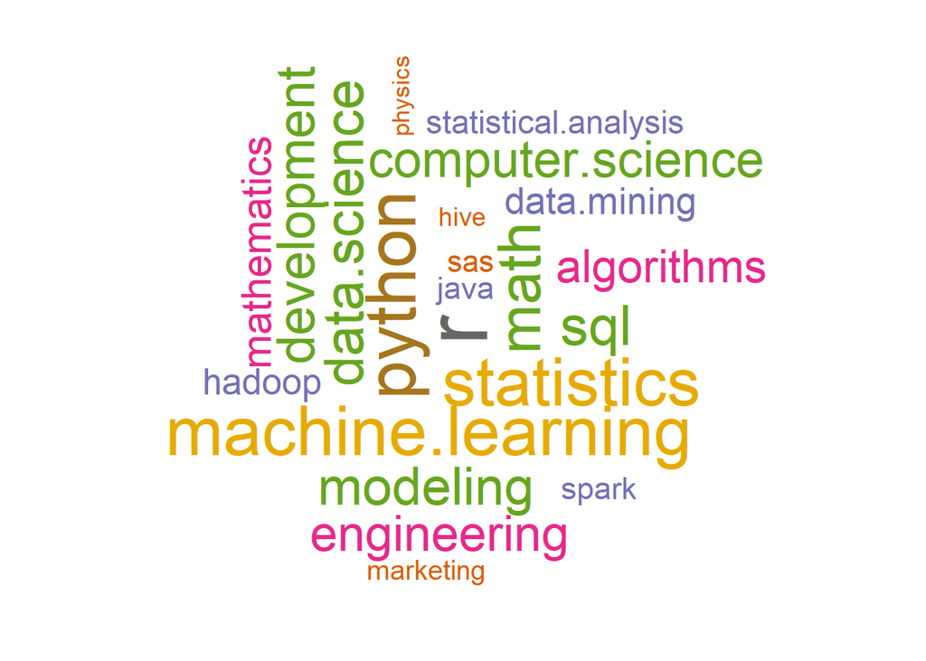

Bar plot of types of companies that hire data scientist:

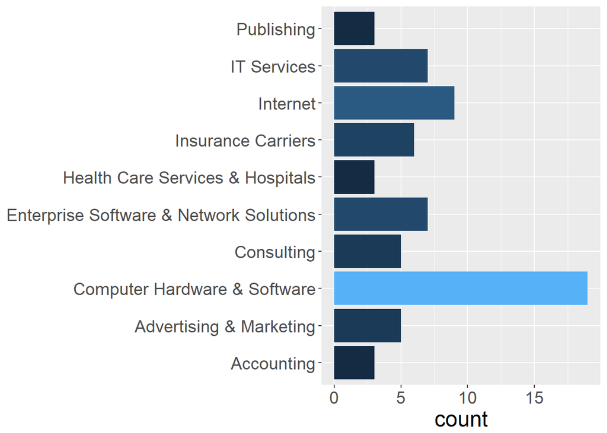

Point plot of geography distribution of companies that hire data scientist:

[figure not shown]